# Project - Plant Seedling Image Classifier

### Background:

Can you differentiate a weed from a crop seedling? The ability to do so effectively can mean better crop yields and better stewardship of the environment. The Aarhus University Signal Processing group, in collaboration with University of Southern Denmark, has recently released a dataset containing images of unique plants belonging to 12 species at several growth stages.

### Objective:

The goal of the project is to create a classifier capable of determining a plant's species from a photo.

### Dataset:

The original files are from Kaggle:

https://www.kaggle.com/c/plant-seedlings-classification/data?select=train

Due to the large volume of data, the images were converted to images.npy file and the labels are also put into the Labels.csv.

- images.npy
- Label.csv

## Import Necessary Libraries & Format Notebook

```python
# Supress warnings
import warnings
warnings.filterwarnings('ignore')

# Import libraries
import numpy as np
import pandas as pd

import cv2

import tensorflow as tf
from tensorflow import keras
from tensorflow.keras.preprocessing.image import ImageDataGenerator
from tensorflow.keras.models import Sequential, load_model
from tensorflow.keras.layers import Dense, Dropout, Activation, Flatten, Conv2D, MaxPooling2D
from tensorflow.keras.callbacks import ModelCheckpoint, EarlyStopping

import matplotlib.pyplot as plt
import seaborn as sns

from sklearn.preprocessing import OneHotEncoder
from sklearn.metrics import classification_report, confusion_matrix
from sklearn.model_selection import train_test_split

# Suppress scientific notation in numpy outputs
np.set_printoptions(suppress=True)
```

```python
# Adjust display and formatting settings
from IPython.core.display import display, HTML
display(HTML("<style>.container { width:98% !important; }</style>"))

np.set_printoptions(precision = 3, linewidth = 500)
pd.options.display.float_format = '{:,.2f}'.format
pd.set_option('display.max_columns', 500)
pd.set_option('display.max_rows', 500)
pd.set_option('display.max_colwidth', 500)
```

```python
# Check tensorflow version
tf.__version__
```

```
'2.3.1'
```

## Load and Explore the Data

```python
# Load image data from images.npy file
images = np.load('./images.npy')

# Load label data from label.csv
labels = pd.read_csv('./Labels.csv')
```

```python
# Print shape of images data
print('Image dataset shape:', images.shape)

# Print shape of label data
print('\nLabel dataset shape:', labels.shape)

# Print number of unique values
print('\nLabel number of unique values:', labels.nunique())

# Check for dataset balance
print('\n', labels.value_counts())
```

```
Image dataset shape: (4750, 128, 128, 3)

Label dataset shape: (4750, 1)

Label number of unique values: Label    12
dtype: int64

 Label
Loose Silky-bent             654
Common Chickweed             611
Scentless Mayweed            516
Small-flowered Cranesbill    496
Fat Hen                      475
Charlock                     390
Sugar beet                   385
Cleavers                     287
Black-grass                  263
Shepherds Purse              231
Maize                        221
Common wheat                 221
dtype: int64
```

```python
# Print first few rows of label data to visualize
labels.head()
```

|  | Label |
| --- | --- |
| 0 | Small-flowered Cranesbill |
| 1 | Small-flowered Cranesbill |
| 2 | Small-flowered Cranesbill |
| 3 | Small-flowered Cranesbill |
| 4 | Small-flowered Cranesbill |

#### Comments:

- Image data contains 4750 of 128x128 pixel RGB color images.
- Label data contains 4750 rows of text format labels.
- Dataset is somewhat unbalanced ranging from 221 to 654 for different classifications.

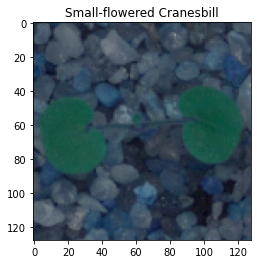

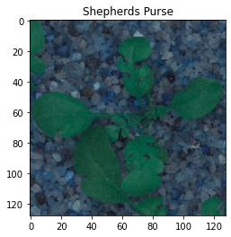

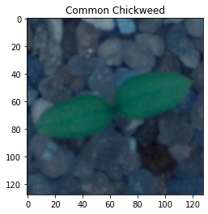

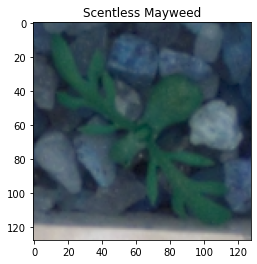

```python
# Visualize a few images from the dataset and the label for each image
for i in range(0, 4000, 1000):
    plt.figure()
    plt.imshow(images[i]);
    plt.title(labels.iloc[i,0]);
```

## Data Preprocessing

```python
# Create X dataset from copying 'images' dataset
X = images.copy()
```

```python
# Normalize the image data
X = X.astype('float32') # Convert to float type
X /= 255.0              # Divide by 255 to normalize
```

```python
# Apply Gaussian Blur
for idx, img in enumerate(X):
  X[idx] = cv2.GaussianBlur(img, (5, 5), 0)
```

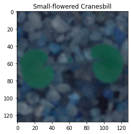

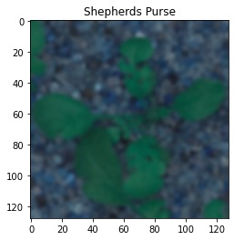

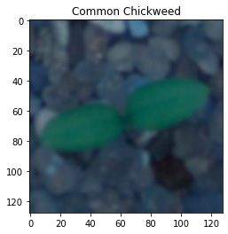

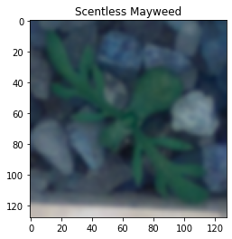

```python
# Visualize a few of the Gaussian Blurred images
for i in range(0, 4000, 1000):
    plt.figure()
    plt.imshow(X[i]);
    plt.title(labels.iloc[i,0]);
```

```python
# Create 'One-Hot' array for our y dataset
y = labels.copy()
y = OneHotEncoder().fit_transform(y).toarray()
y
```

```
array([[0., 0., 0., ..., 0., 1., 0.],
       [0., 0., 0., ..., 0., 1., 0.],
       [0., 0., 0., ..., 0., 1., 0.],
       ...,
       [0., 0., 0., ..., 0., 0., 0.],
       [0., 0., 0., ..., 0., 0., 0.],
       [0., 0., 0., ..., 0., 0., 0.]])
```

#### Split Data into Train, Test, and Validation Sets

```python
# First - Split X and y into Training / Test sets
X_train, X_test, y_train, y_test = train_test_split(X, y, train_size=0.7, random_state=0)

# Second - Split 'Test' set into 'Test' and 'Validation' sets
X_test, X_val, y_test, y_val = train_test_split(X_test, y_test, train_size=0.5, random_state=0)
```

```python
# Check shapes of our training, test, and validation sets
print('X_train: {}   y_train: {}'.format(X_train.shape, y_train.shape))
print(' X_test: {}     y_test: {}'.format(X_test.shape, y_test.shape))
print('  X_val: {}      y_val: {}'.format(X_val.shape, y_val.shape))
```

```
X_train: (3325, 128, 128, 3)   y_train: (3325, 12)
 X_test: (712, 128, 128, 3)     y_test: (712, 12)
  X_val: (713, 128, 128, 3)      y_val: (713, 12)
```

### Comments:

- We now have our model datasets created and proportioned into train, test, and validation sets.
- The 'y' datasets are one-hot-encoded into 12 categories.
- The 'X' datasets are in a compatible format for Keras.

## Build CNN Model

```python
# Clear the session and set a random seed
tf.keras.backend.clear_session()
tf.random.set_seed(1)

# Initiate the model and define layers
nn_1 = tf.keras.models.Sequential([Conv2D(32, (3, 3), input_shape=X_train.shape[1:], activation = 'relu', padding = 'same'),
                                   MaxPooling2D(pool_size = (2, 2)),
                                   Conv2D(32, (3, 3), activation = 'relu', padding = 'same'),
                                   MaxPooling2D(pool_size = (2, 2)),
                                   Conv2D(32, (3, 3), activation = 'relu', padding = 'valid'),
                                   MaxPooling2D(pool_size = (2, 2)),
                                   Flatten(),
                                   Dense(units = 512, activation = 'relu'),
                                   Dropout(0.5),
                                   Dense(units = 128, activation = 'relu'),
                                   Dense(units = 12, activation = 'softmax')])

# Print a summary
print(nn_1.summary())
```

```
Model: "sequential"
_________________________________________________________________
Layer (type)                 Output Shape              Param #
=================================================================
conv2d (Conv2D)              (None, 128, 128, 32)      896
_________________________________________________________________
max_pooling2d (MaxPooling2D) (None, 64, 64, 32)        0
_________________________________________________________________
conv2d_1 (Conv2D)            (None, 64, 64, 32)        9248
_________________________________________________________________
max_pooling2d_1 (MaxPooling2 (None, 32, 32, 32)        0
_________________________________________________________________
conv2d_2 (Conv2D)            (None, 30, 30, 32)        9248
_________________________________________________________________
max_pooling2d_2 (MaxPooling2 (None, 15, 15, 32)        0
_________________________________________________________________
flatten (Flatten)            (None, 7200)              0
_________________________________________________________________
dense (Dense)                (None, 512)               3686912
_________________________________________________________________
dropout (Dropout)            (None, 512)               0
_________________________________________________________________
dense_1 (Dense)              (None, 128)               65664
_________________________________________________________________
dense_2 (Dense)              (None, 12)                1548
=================================================================
Total params: 3,773,516
Trainable params: 3,773,516
Non-trainable params: 0
_________________________________________________________________
None
```

#### Set Optimizer and Loss function

```python
# Add loss function, optimizer and evaluation metric to the model
nn_1.compile(optimizer = 'adam',
             loss = 'categorical_crossentropy',
             metrics = ['accuracy'])
```

#### Train the Model

```python
%%time
# Add constraints and record best weights to resume
callbacks = [
    EarlyStopping(
        monitor='val_loss',             # Monitor validation loss history
        min_delta=0.001,                # Stop training when validation loss is no longer improving by at least 0.001
        patience=10,                    # Look at validation loss improvement over the last 10 epochs
        verbose=1),
]

# Train the model
nn_1.fit(X_train, y_train, validation_data = (X_test, y_test), callbacks=callbacks, epochs = 40, verbose = 1)
```

```
Epoch 00020: early stopping
Wall time: 10min 41s
```

```
<tensorflow.python.keras.callbacks.History at 0x270bc9f7a08>
```

#### Save the Model and Weights

```python
nn_1.save('./nn_1_model.h5')
nn_1.save_weights('./nn_1_weights.h5')
```

#### Load the Model with Weights

```python
nn_1_trained = load_model('./nn_1_model.h5')
nn_1_trained.load_weights('./nn_1_weights.h5')
```

#### Score the Trained Model

```python
scores = nn_1.evaluate(X_test, y_test, verbose=1)
print('Test loss:', scores[0])
print('Test accuracy:', scores[1])
```

```
Test loss: 0.9434108138084412
Test accuracy: 0.7780898809432983
```

```python
# Create probabilities for each class
y_pred = nn_1_trained.predict(X_test)
y_pred_class = np.argmax(y_pred, axis=1)
y_test_class = np.argmax(y_test, axis=1)
```

```python
# Printing the classification report
print(classification_report(y_test_class, y_pred_class))
```

```
              precision    recall  f1-score   support

           0       0.32      0.27      0.29        37
           1       0.73      0.98      0.84        50
           2       0.86      0.82      0.84        51
           3       0.89      0.93      0.91        95
           4       0.60      0.74      0.67        35
           5       0.91      0.79      0.84        85
           6       0.74      0.72      0.73        96
           7       0.66      0.81      0.72        26
           8       0.71      0.70      0.71        77
           9       0.87      0.65      0.74        40
          10       0.90      0.90      0.90        60
          11       0.83      0.80      0.81        60

    accuracy                           0.78       712
   macro avg       0.75      0.76      0.75       712
weighted avg       0.78      0.78      0.78       712
```

#### Create a confusion matrix

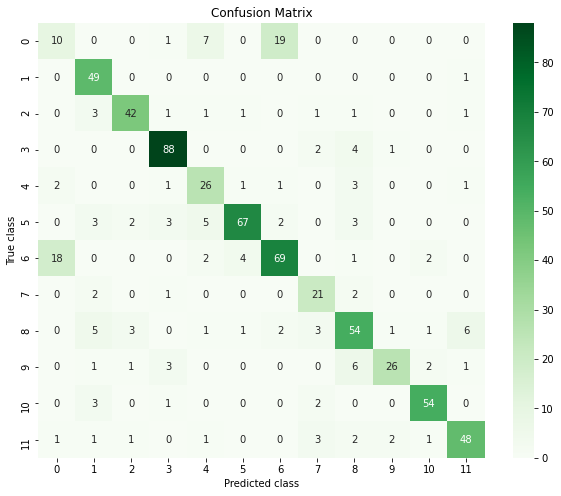

```python
# Create the Confusion Matrix and plot using Heat Map
cnf_matrix = confusion_matrix(y_test_class, y_pred_class)

fig, ax = plt.subplots(1,figsize=(10, 8))
ax = sns.heatmap(cnf_matrix, ax=ax, cmap=plt.cm.Greens, annot=True)
#ax.set_xticklabels(labels)
#ax.set_yticklabels(labels)
plt.title('Confusion Matrix')
plt.ylabel('True class')
plt.xlabel('Predicted class')
#fig.savefig('Confusion matrix.png', dpi=300)
plt.show();
```

#### Visualize Predictions on Several Images

```python
# Create function predict for an individual image
def predict_image(img):
    prediction = nn_1_trained.predict(np.expand_dims(img, axis = 0))
    print('\nImage Class Probablities:', prediction)
    print('\n         Predicted class: %.0f' % np.argmax(prediction))
    plt.figure()
    plt.imshow(img);
```

```
Image Class Probablities: [[0.    0.    0.    0.042 0.    0.    0.    0.069 0.653 0.    0.    0.236]]

         Predicted class: 8
```

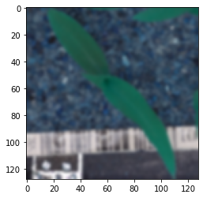

```python
# Prediction for image X_test[2]
predict_image(X_test[2])
```

```
Image Class Probablities: [[0. 0. 0. 0. 0. 0. 0. 0. 0. 0. 1. 0.]]

         Predicted class: 10
```

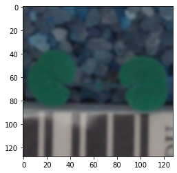

```python
# Prediction for image X_test[3]
predict_image(X_test[3])
```

```
Image Class Probablities: [[0.    0.    0.    0.045 0.    0.    0.    0.002 0.94  0.01  0.    0.004]]

         Predicted class: 8
```

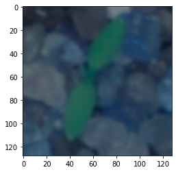

```python
# Prediction for image X_test[33]
predict_image(X_test[33])
```

```
Image Class Probablities: [[0.    0.    0.    0.001 0.    0.999 0.    0.    0.    0.    0.    0.   ]]

         Predicted class: 5
```

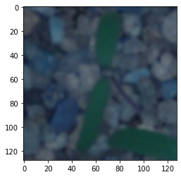

```python
# Prediction for image X_test[36]
predict_image(X_test[36])
```

```
Image Class Probablities: [[0.    0.939 0.    0.    0.    0.    0.    0.001 0.    0.    0.    0.061]]

         Predicted class: 1
```

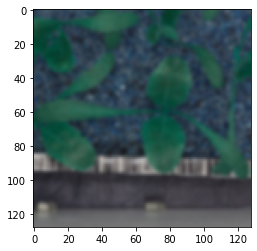

```python
# Prediction for image X_test[59]
predict_image(X_test[59])
```

## Summary

- The goal of this project was to create a CNN classifier capable of predicting a plant's species from a photo.
- We tried only one CNN model architecture and were able to achieve about 78% prediction accuracy with it.
- We could probably improve this greatly by testing additional CNN architectures.
- We could test additional CNN models using train and test data, then test our final model on the validation data.